# Tutorial: Basic matching and stitching in R

10 May, 2021

# 1 Goal

This tutorial was designed to show how to use the R functions to match based on the nearest neighbor and use these matches to stitch the synthetic data together into a ts. For now the target data is actual ESM data so that we can compare the stitched data to existing data to validate our emulation process.

# 2 Set Up

```r
set.seed(1)
# required packages
library(dplyr)
library(tidyr)
library(ggplot2)
library(knitr)

# Then load the functions we will want to use, these are currently written in R and will be translated into python.
source("functions/nearest_neighbor_matching.R") # the function match_neighborhood is defined here
source("functions/permuting_matches.R")  # the function permute_stitching_recipe is defined here
source("functions/stitching_functions.R")  # the function stitch_global_mean is definend here
source("functions/gridded_recipe.R") # wrappers for the work flow from matching to output csv needed by python for
                                     # layering in gridded data to output as netcdf
```

Load the inputs that will be used in the tutorial.

```r
# Time series of the raw global mean temperature anomaly, this is the data that is
# going to be stitched together. Historical data is pasted into every scenario. No
# smoothing has been done.
tgav_data <- read.csv("inputs/main_raw_pasted_tgav_anomaly_all_pangeo_list_models.csv",
                      stringsAsFactors = FALSE) %>% dplyr::select(-X)


# A chunked smoothed tgav anomaly archive of data. This was tgav_data but several
# steps were taken in python to transform it into the "chunked" data and save it
# so that we do not have to repeate this process so many times.
archive_data <- read.csv('inputs/archive_data.csv', stringsAsFactors = FALSE)


# This is chunked smooth tgav anomaly for a single model/experiment/ensemble
# member, saved for our convenience. If you decide that you want to work with
# a different different target data subset you can subset it from the
# archive_data data frame. This file is SSP245 Realization 1.
target_data <- read.csv("inputs/target_data.csv", stringsAsFactors = FALSE)

# target data 2: ssp245 realization 4
archive_data %>%
  filter(experiment == 'ssp245' & ensemble == 'r4i1p1f1') ->
  target_data2
```

# 3 Matching

Use the function `match_neighborhood` to match the target and archive data to one another. Right now the user will have to manually subset the contents of the archive so that we are not matching to other ESMs *or* the target scenario.

For the target data of CanESM5 SSP245, this archive consists of all other CanESM5 scenarios except ssp534-over. We’ve run into some data problems with that scenario and are excluding it for now. Additional filtering, for example to just SSP126 and SSP585, would be done by updating this block of code.

```r
archive_data %>%
  # Only match to the same ESM:
  dplyr::filter(model == unique(target_data$model)) %>%
  # Don't match to any ensemble members in the target experiment:
  dplyr::filter(experiment != unique(target_data$experiment) ) %>%
  # Exclude ssp534-over:
  dplyr::filter(experiment != 'ssp534-over') ->
  archive_subset
```

Now that we have the subset of the archive we want to work with, we can use it in the matching with a specified tolerance on neighborhoods. The matching function can also handle matching for multiple targets.

Match the target and archive data!

```r
matched_data <- match_neighborhood(target_data = bind_rows(target_data, target_data2),
                                   archive_data = archive_subset,
                                   tol = 0.1)
```

```r
head(matched_data)
```

|  | target_variable | target_experiment | target_ensemble | target_model | target_start_yr | target_end_yr | target_year | target_fx | target_dx | archive_experiment | archive_variable | archive_model | archive_ensemble | archive_start_yr | archive_end_yr | archive_year | archive_fx | archive_dx | dist_dx | dist_fx | dist_l2 |
| --- | --- | --- | --- | --- | --- | --- | --- | --- | --- | --- | --- | --- | --- | --- | --- | --- | --- | --- | --- | --- | --- |
| 1 | tgav | ssp245 | r1i1p1f1 | CanESM5 | 1850 | 1858 | 1854 | -1.28987 | -0.003368119 | ssp119 | tgav | CanESM5 | r4i1p1f1 | 1895 | 1903 | 1899 | -1.297148 | -0.003627395 | 0.002074211 | 0.007277623 | 0.00756744 |
| 2 | tgav | ssp245 | r1i1p1f1 | CanESM5 | 1850 | 1858 | 1854 | -1.28987 | -0.003368119 | ssp119 | tgav | CanESM5 | r8i1p1f1 | 1850 | 1858 | 1854 | -1.317887 | 0.006824218 | 0.081538693 | 0.028017188 | 0.08621787 |
| 3 | tgav | ssp245 | r1i1p1f1 | CanESM5 | 1850 | 1858 | 1854 | -1.28987 | -0.003368119 | ssp119 | tgav | CanESM5 | r6i1p1f1 | 1859 | 1867 | 1863 | -1.329943 | -0.005897687 | 0.020236546 | 0.040073372 | 0.04489313 |
| 4 | tgav | ssp245 | r1i1p1f1 | CanESM5 | 1850 | 1858 | 1854 | -1.28987 | -0.003368119 | ssp119 | tgav | CanESM5 | r18i1p1f1 | 1904 | 1912 | 1908 | -1.325681 | -0.002808887 | 0.004473854 | 0.035811017 | 0.03608939 |
| 5 | tgav | ssp245 | r1i1p1f1 | CanESM5 | 1850 | 1858 | 1854 | -1.28987 | -0.003368119 | ssp119 | tgav | CanESM5 | r16i1p1f1 | 1868 | 1876 | 1872 | -1.248082 | -0.002117625 | 0.010003950 | 0.041787995 | 0.04296877 |
| 6 | tgav | ssp245 | r1i1p1f1 | CanESM5 | 1850 | 1858 | 1854 | -1.28987 | -0.003368119 | ssp119 | tgav | CanESM5 | r15i1p1f1 | 1859 | 1867 | 1863 | -1.306119 | 0.002410833 | 0.046231611 | 0.016249435 | 0.04900414 |

Visualize the matched points.

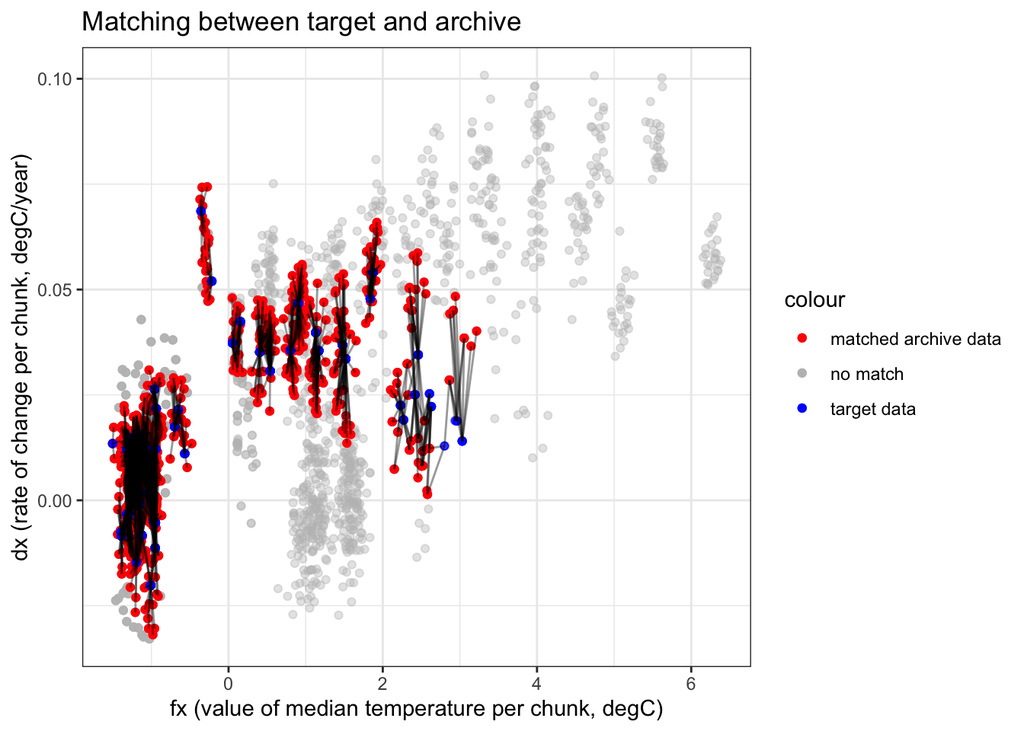

```r
ggplot(data = matched_data) +
  # Add the subset of the archive data that was read into the matching process.
  geom_point(data = archive_subset, aes(fx, dx, color = "no match"), alpha = 0.4) +
  # Add the matched together points and make clear which points are matched with which.
  geom_point(aes(archive_fx, archive_dx, color = "matched archive data")) +
  geom_point(aes(target_fx, target_dx,  color = "target data"), alpha = 0.4) +
  # Add lines between the matched values
  geom_segment(aes(x = target_fx, y = target_dx, xend = archive_fx, yend =  archive_dx), alpha = 0.4) +
 scale_color_manual(values = c("matched archive data" = "red",
                               "target data" = "blue", "no match" = "grey"))+
  theme_bw() +
  labs(y = "dx (rate of change per chunk, degC/year)",
       x = "fx (value of median temperature per chunk, degC)",
       title = "Matching between target and archive" )
```

# 4 Turn matched points into stitching recipes

The results of our matching are straightforward - a data frame that has every target window and all of the potential matches to each window. This results in many potential stitched Tgav scenarios when all possible permutations are mixed and matched (`totalNumPerms`). To avoid collapse in our generated Tgav time series, however, each target is limited to generate N new Tgav values (N = smallest number of matches of any target_window for each target_ensemble; `minNumMatches`). In other words, if a target has a time window with only two matches, all generated Tgav values will go through one of those two values in that time window, and trajectory collapse will occur.

```r
kable(get_num_perms(matched_data)[[1]])
```

| target_variable | target_experiment | target_ensemble | target_model | totalNumPerms | minNumMatches |
| --- | --- | --- | --- | --- | --- |
| tgav | ssp245 | r1i1p1f1 | CanESM5 | 2.081113e+40 | 2 |
| tgav | ssp245 | r4i1p1f1 | CanESM5 | 7.586513e+38 | 3 |

Our function `permute_stitching_recipes` takes a data frame of matched data and does random draws to get recipes for each Tgav.

If multiple target ensembles are included in `matched_data`, the function draws recipes for the ensemble with the smallest number of collapse-free scenarios upwards. Because these are random draws and target ensembles of the same experiment often have similar values in each window and therefore match to similar archive values, sometimes the 2nd+ target ensemble will get fewer than its potential number of collapse-free generated recipes, depending on the RNG. If you ask for more matches than an ensemble can have, the function will just give you as many recipes as it can.

The lack of collapse is enforced across all target ensembles fed to `permute_stitching_recipes`. If you don’t want *any* of your generated Tgavs to have collapse, you can just directly feed the matched data into the function. If you don’t want any collapse within each set of generated Tgavs for each target realization but don’t care about collapse across targets, you can subset `matched_data` by target and apply `permute_stitching_recipes` separately to each piece.

`permute_stitching_recipes` does not support `matched_data` that contains targets from more than one *experiment*. The function must be called separately for each experiment.

Finally, the function `permute_stitching_recipes` also makes sure that within any individual generated Tgav time series, you don’t get a repetition of matches. In other words, target years 1989 and 1998 cannot be matched to the same archive point. If such a duplication occurs, the target year that is closer to the archive point keeps that point. The other target year gets re-matched to the nearest neighbor in a ‘new’ archive (the initial archive used for matching minus all archive points that have already been matched to a target).

```r
recipes <- permute_stitching_recipes(N_matches = 3,
                                     matched_data = matched_data,
                                     archive = archive_subset)
```

```
## You have requested more recipes than possible for at least one target trajectories, returning what can
```

```r
kable(head(recipes))
```

[output not shown]

# 5 Stitching and plotting

Subset the raw tgav anomalies to include only the modelXscenarioXensemble of the target data as comparison data for the constructed tgav anomalies. These are our original data we’ll want to compare generated ensemble members to.

```r
# For plotting - ssp245 realization 1
tgav_data %>%
  filter(model == unique(target_data$model) & experiment == unique(target_data$experiment) &
           ensemble == unique(target_data$ensemble)) ->
  original_data1

# for plotting - ssp245 realization 4
tgav_data %>%
  filter(model == unique(target_data2$model) & experiment == unique(target_data2$experiment) &
           ensemble == unique(target_data2$ensemble)) ->
  original_data2
```

Now that we have a data frame with matched information, use the function `stitch_global_mean` to produce the stiched data.

[figure not shown]

```r
stitch_global_mean(recipes=recipes, data = tgav_data) ->
  out1
```

# 6 Full Pipeline

## 6.1 Single pipeline of code

Reduced set of code calls to go from target and archive data through to new Tgavs:

```r
match_neighborhood(target_data = bind_rows(target_data, target_data2),
                   archive_data = archive_subset,
                   tol=0.1) %>%
  # Convert them to a sample of individual Tgav Recipes:
  permute_stitching_recipes(N_matches = 5, matched_data = .,
                            archive = archive_subset)  %>%
  # And stitch the recipes into tgavs:
  stitch_global_mean(recipes=., data = tgav_data) ->
  rslts
```

```
## You have requested more recipes than possible for at least one target trajectories, returning what can
```

```r
head(rslts)
```

|  | year | value | variable | stitching_id |
| --- | --- | --- | --- | --- |
| ssp245~r1i1p1f1~1.1 | 1850 | -1.293088 | tgav | ssp245~r1i1p1f1~1 |
| ssp245~r1i1p1f1~1.2 | 1851 | -1.248485 | tgav | ssp245~r1i1p1f1~1 |
| ssp245~r1i1p1f1~1.3 | 1852 | -1.374905 | tgav | ssp245~r1i1p1f1~1 |
| ssp245~r1i1p1f1~1.4 | 1853 | -1.432868 | tgav | ssp245~r1i1p1f1~1 |
| ssp245~r1i1p1f1~1.5 | 1854 | -1.377962 | tgav | ssp245~r1i1p1f1~1 |
| ssp245~r1i1p1f1~1.6 | 1855 | -1.354551 | tgav | ssp245~r1i1p1f1~1 |

## 6.2 Varying archive and tolerance for matching

You can change the stitched outputs by changing the experiments included in the archive (or the tolerance used for matching).

All matches on 0.2degC neighborhood, for variety

```r
# Subset the archive data to exlude a single experiment at a time.
archive_subset %>%
  filter(experiment != "ssp119"&
                  experiment!= 'ssp534-over') %>%
  # Use that data to match with the target data.
  match_neighborhood(target_data = bind_rows(target_data, target_data2),
                   archive_data = .,
                   tol=0.2) %>%
  # Convert them to a sample of individual Tgav Recipes:
  permute_stitching_recipes(N_matches = 3, matched_data = .,
                            archive = archive_subset)  %>%
  # And stitch the recipes into tgavs:
  stitch_global_mean(recipes=., data = tgav_data) %>%
  # label so we know which archive it came from
  mutate(scn = 'archive1') ->
  out1


archive_subset %>%
  filter(experiment != "ssp126"&
                  experiment!= 'ssp534-over') %>%
    # Use that data to match with the target data.
  match_neighborhood(target_data = bind_rows(target_data, target_data2),
                   archive_data = .,
                   tol=0.2) %>%
  # Convert them to a sample of individual Tgav Recipes:
  permute_stitching_recipes(N_matches = 3, matched_data = .,
                            archive = archive_subset)  %>%
  # And stitch the recipes into tgavs:
  stitch_global_mean(recipes=., data = tgav_data) %>%
  # label so we know which archive it came from
  mutate(scn = "archive2") ->
  out2

archive_subset %>%
  filter(experiment != "ssp370"&
                  experiment!= 'ssp534-over') %>%
   # Use that data to match with the target data.
  match_neighborhood(target_data = bind_rows(target_data, target_data2),
                   archive_data = .,
                   tol=0.2) %>%
  # Convert them to a sample of individual Tgav Recipes:
  permute_stitching_recipes(N_matches = 3, matched_data = .,
                            archive = archive_subset)  %>%
  # And stitch the recipes into tgavs:
  stitch_global_mean(recipes=., data = tgav_data) %>%
  # label so we know which archive it came from
  mutate(scn = "archive3") ->
  out3


rslts <- rbind(out1, out2, out3)
```

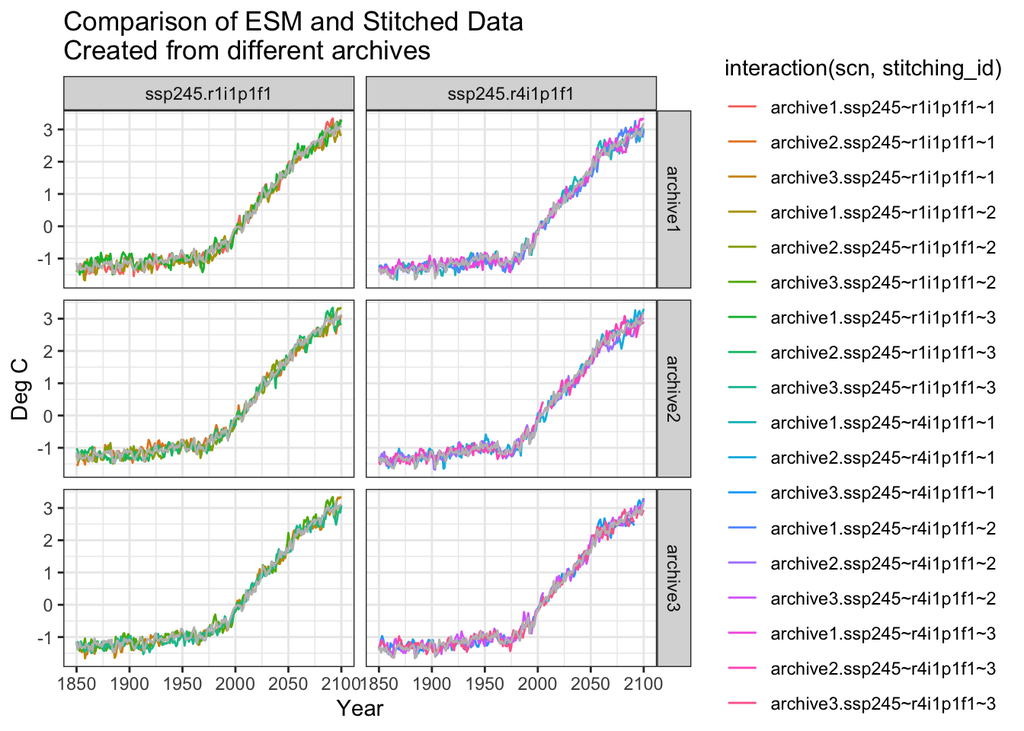

```r
rslts %>%
  mutate(tosep = stitching_id) %>%
  separate(tosep, c('experiment', 'ensemble', 'trash'), sep = "~") %>%
  select(-trash) %>%
  left_join(select(bind_rows(original_data1, original_data2), -timestep, -grid_type, -file) %>%
              rename(orig_val = value),
            by = c('year', 'variable', 'experiment', 'ensemble')) ->
  plotting_tgavs
ggplot() +
  facet_grid(scn~interaction(plotting_tgavs$experiment, plotting_tgavs$ensemble)) +
  geom_line(data = plotting_tgavs ,
                          aes(year, value, color = interaction(scn, stitching_id))) +
  geom_line(data = plotting_tgavs, aes(x = year, y = orig_val), color = "grey", size = 0.5) +
  theme_bw() +
  labs(title = "Comparison of ESM and Stitched Data\nCreated from different archives",
       x = "Year", y = "Deg C")
```

You can also generate new SSP245 realizations by using the other CanESM5 realizations from the `archive_data` as the `target_data` in the above pipeline. For now, because we have nearest neighbor matching implemented, this is the limit of the number of constructed realizations that can be made. For CanESM5, there are 25 SSP245 realizations - using each of these as target data and adjusting which of the other scenarios are included in the archive should give a few hundred realizations to work with evaluating while Kalyn and Abigail implement the neighborhood matching instead of selecting the single nearest neighbor.